# Random Forests and Bagging

# Experiment Part 2

## 100 Resamples

```r
set.seed(1)

# Initialize
classes <- rep(0,100)

# Loop
for(i in 0:100){
    # Take a resample
    re_land <- sample_n(land, nrow(land), replace = TRUE)

    # Construct a tree
    re_tree <- rpart(class ~ ., re_land, cp = -1)

    # Make and store a prediction
    classes[i] = levels(land$class)[predict(re_tree, newdata = land[2,], type = "class")]
}
```

## 100 Tree Classification

```r
class_preds <- data.frame(Class = classes)
prediction <- class_preds %>%
  group_by(Class) %>%
  summarize(count = n()) %>%
  arrange(desc(count))

head(prediction)
```

```
## # A tibble: 4 x 2
##   Class       count
##   <fct>       <int>
## 1 "concrete "    87
## 2 "building "    10
## 3 "soil "         2
## 4 "car "          1
```

From the above we can see that our prediction using 100 trees is concrete!

## Baggin in RStudio

Note, random forests are good because they decorrelate all of our trees from the different predictors.

### A)

```r
# set the seed
set.seed(200)

# obtain a bagged classification
bagging_R <- randomForest(class ~ ., land, ntree = 100, mtry = 147)
#ntree = number of trees
#mtry = number of predictors to use (all 147 in this case)
```

```r
print(bagging_R)
```

```
##
## Call:
##  randomForest(formula = class ~ ., data = land, ntree = 100, mtry = 147)
##                Type of random forest: classification
##                      Number of trees: 100
## No. of variables tried at each split: 147
##
##         OOB estimate of  error rate: 13.78%
## Confusion matrix:
##           asphalt  building  car  concrete  grass  pool  shadow  soil
## asphalt         55         0    0         1      0     0       2     1
## building         4       104    2        10      0     0       0     2
## car              1         1   32         2      0     0       0     0
## concrete         0        13    3        96      0     0       0     4
## grass            0         1    0         0     99     0       0     0
## pool             0         0    1         0      1    26       1     0
## shadow           5         0    0         0      0     0      55     0
## soil             0         5    0         4      3     0       0    22
## tree             0         0    0         1     10     0       2     0
##           tree  class.error
## asphalt       0  0.06779661
## building      0  0.14754098
## car           0  0.11111111
## concrete      0  0.17241379
## grass        12  0.11607143
## pool          0  0.10344828
## shadow        1  0.09836066
## soil          0  0.35294118
## tree         93  0.12264151
```

The 00B error rate is 13.78%.

## Forests VS Bagging

Random forests decorrelate the data of our predictors from the trees, making it a better algorithm than bagging. They also are computationally for efficient since they make smaller trees than bagging.

## Forests In RStudio

### A)

sqrt(147) = 12

### B)

To construct a 100 tree forest:

```r
# set the seed
set.seed(200)

# obtain a forest
forest_R <- randomForest(class ~ ., land, ntree = 100, mtry = sqrt(147)) #Note, if we leave out this mtry section, it will defaut to the sqrt of our number of predictors
```

### C)

```r
print(forest_R)
```

```
##
## Call:
##  randomForest(formula = class ~ ., data = land, ntree = 100, mtry = sqrt(147))
##                Type of random forest: classification
##                      Number of trees: 100
## No. of variables tried at each split: 12
##
##         OOB estimate of  error rate: 13.78%
## Confusion matrix:
##           asphalt  building  car  concrete  grass  pool  shadow  soil
## asphalt         53         1    1         0      0     0       2     1
## building         3       104    3        11      0     0       0     1
## car              0         0   34         2      0     0       0     0
## concrete         0        14    3        95      0     0       0     3
## grass            0         1    0         0     96     0       0     2
## pool             0         0    1         0      1    26       1     0
## shadow           3         0    0         0      0     0      56     0
## soil             0         4    0         3      3     0       0    24
## tree             1         0    0         1      8     0       2     0
##           tree  class.error
## asphalt       1  0.10169492
## building      0  0.14754098
## car           0  0.05555556
## concrete      1  0.18103448
## grass        13  0.14285714
## pool          0  0.10344828
## shadow        2  0.08196721
## soil          0  0.29411765
## tree         94  0.11320755
```

### D)

This gets the most important predictors by calculating their gini_index:

```r
# unarranged
forest_R$importance
```

```
##               MeanDecreaseGini
## BrdIndx              0.6354773
## Area                 5.5877845
## Round                0.7947853
## Bright              10.8481366
## Compact              1.4910135
## ShpIndx              1.5641179
## Mean_G              10.8430599
## Mean_R              12.2638476
## Mean_NIR            13.8806832
## SD_G                 5.2271811
## SD_R                 2.4449895
## SD_NIR               5.7124292
## LW                   1.0938535
## GLCM1                1.3453817
## Rect                 0.7261510
## GLCM2                0.9064561
## Dens                 1.7952313
## Assym                1.0940716
## NDVI                30.5495111
## BordLngth            4.5391249
## GLCM3                1.9145062
## BrdIndx_40           1.7066170
## Area_40              4.1020286
## Round_40             1.1039647
## Bright_40            8.6753380
## Compact_40           1.0431990
## ShpIndx_40           1.8413833
## Mean_G_40           12.0567719
## Mean_R_40           13.8273870
## Mean_NIR_40         10.6353642
## SD_G_40              5.3148772
## SD_R_40              2.9782055
## SD_NIR_40            3.3639898
## LW_40                0.8749022
## GLCM1_40             1.9828242
## Rect_40              0.6867600
## GLCM2_40             1.0510721
## Dens_40              1.0354413
## Assym_40             1.3445007
```

[output cut: 93 more lines]

```
## Mean_G_140           4.6413316
## Mean_R_140           3.8995829
## Mean_NIR_140         7.4552773
## SD_G_140             2.7945427
## SD_R_140             1.7127147
## SD_NIR_140           2.0494305
## LW_140               0.9796488
## GLCM1_140            0.7122851
## Rect_140             1.1176329
## GLCM2_140            1.1316528
## Dens_140             1.8321097
## Assym_140            1.7247679
## NDVI_140             2.9532684
## BordLngth_140        2.5676318
## GLCM3_140            0.9940934
```

```r
# arranged
data.frame(names = row.names(forest_R$importance), forest_R$importance) %>%
    arrange(desc(MeanDecreaseGini))
```

```
##             names MeanDecreaseGini
## 1            NDVI       30.5495111
## 2         NDVI_40       20.2502513
## 3        Mean_NIR       13.8806832
## 4       Mean_R_40       13.8273870
## 5         NDVI_60       13.5573902
## 6         NDVI_80       13.1987744
## 7       Mean_R_60       12.3361116
## 8          Mean_R       12.2638476
## 9       Mean_G_40       12.0567719
## 10         Bright       10.8481366
## 11         Mean_G       10.8430599
## 12    Mean_NIR_40       10.6353642
## 13      Bright_60        9.5725138
## 14    Mean_NIR_60        9.5078712
```

[output cut: 133 more lines]

From this we can see that the most important predictor is NDVI, and the least important is BrdIndx.

### E)

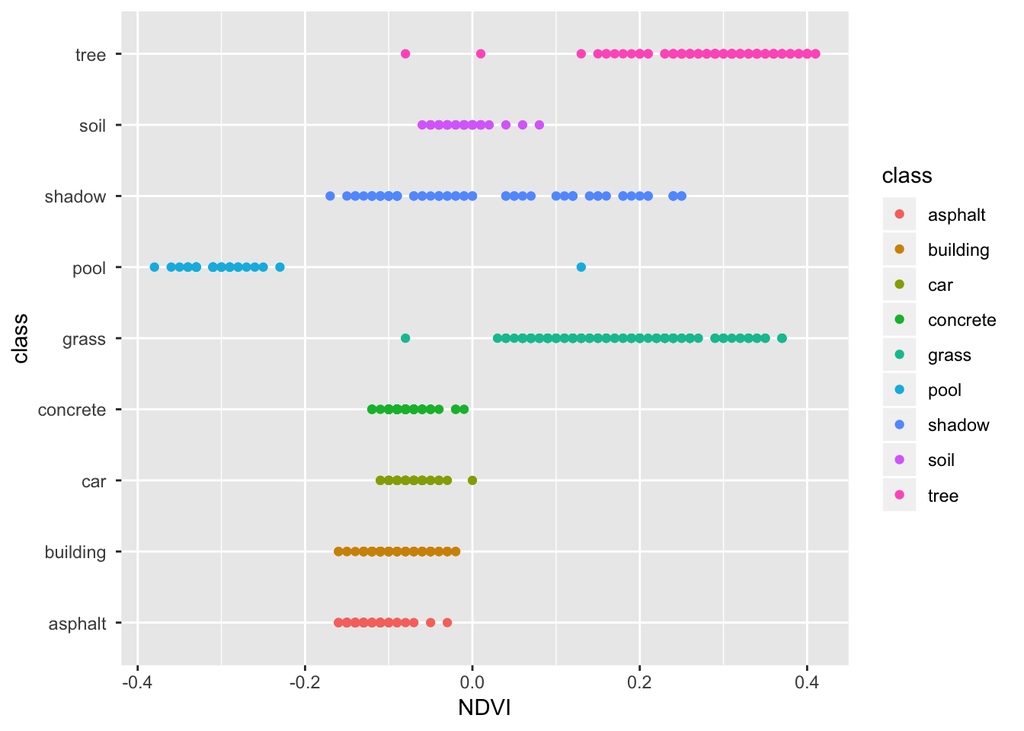

```r
ggplot(land, aes(x=NDVI, y=class, color=class)) + geom_point()
```